# 2.4 Cross-cell-line LOY vs sgCTRL — combined (HT1080, A549, LNCaP)

### A549 vs LNCaP

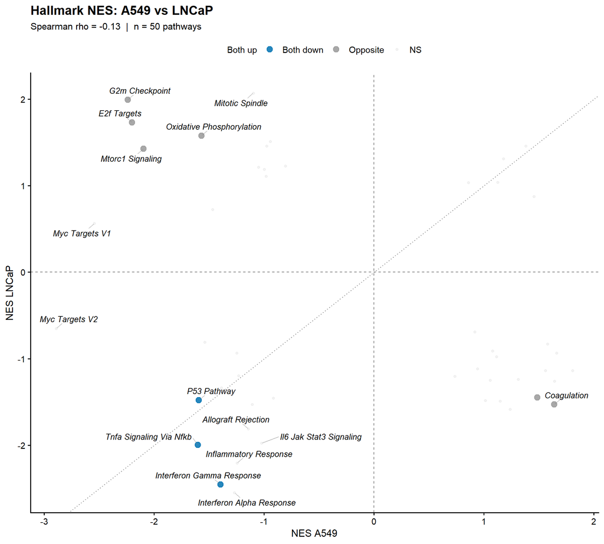

```
## Saved: hallmark_nes_scatter_A549_vs_LNCaP.(png|pdf)  [10x9 in]
```

Compact 3-panel composite for publication (saved only):

## 6.5 Pairwise NES scatter — Reactome / KEGG / GO:BP

Same pairwise structure as §6.4, but on the larger MSigDB collections. Top-N labels per panel are scaled to the collection size (Reactome ~1600 sets, KEGG ~190, GO:BP ~7500), so the most-extreme pathways stand out without saturating the figure.

```
## Pathways scored in all 3 lines per collection:
```

```
##   Reactome  952
##   KEGG      154
##   GO:BP     3373
```

### Reactome

#### HT1080 vs A549

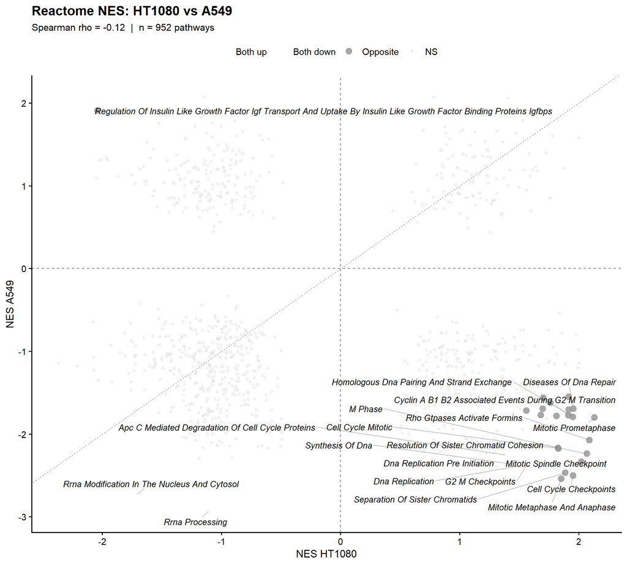

```
## Saved: reactome_nes_scatter_HT1080_vs_A549.(png|pdf)  [10x9 in]
```

#### HT1080 vs LNCaP

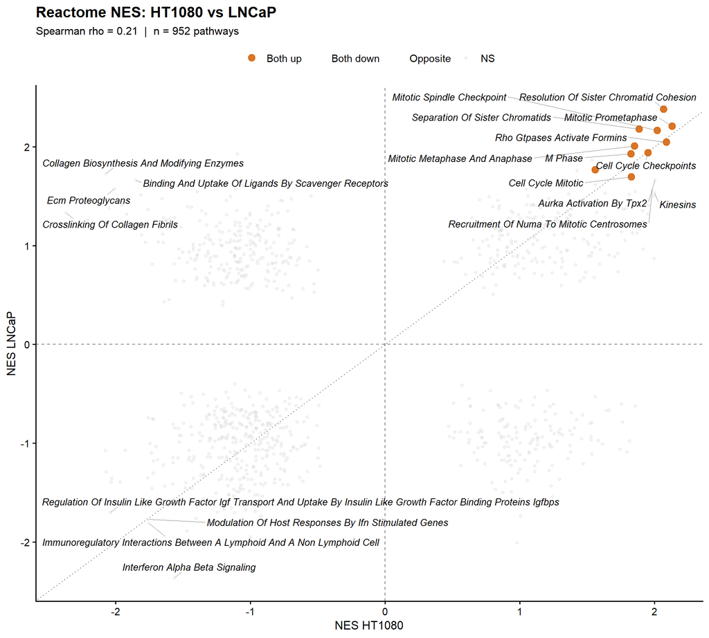

```
## Saved: reactome_nes_scatter_HT1080_vs_LNCaP.(png|pdf)  [10x9 in]
```

#### A549 vs LNCaP

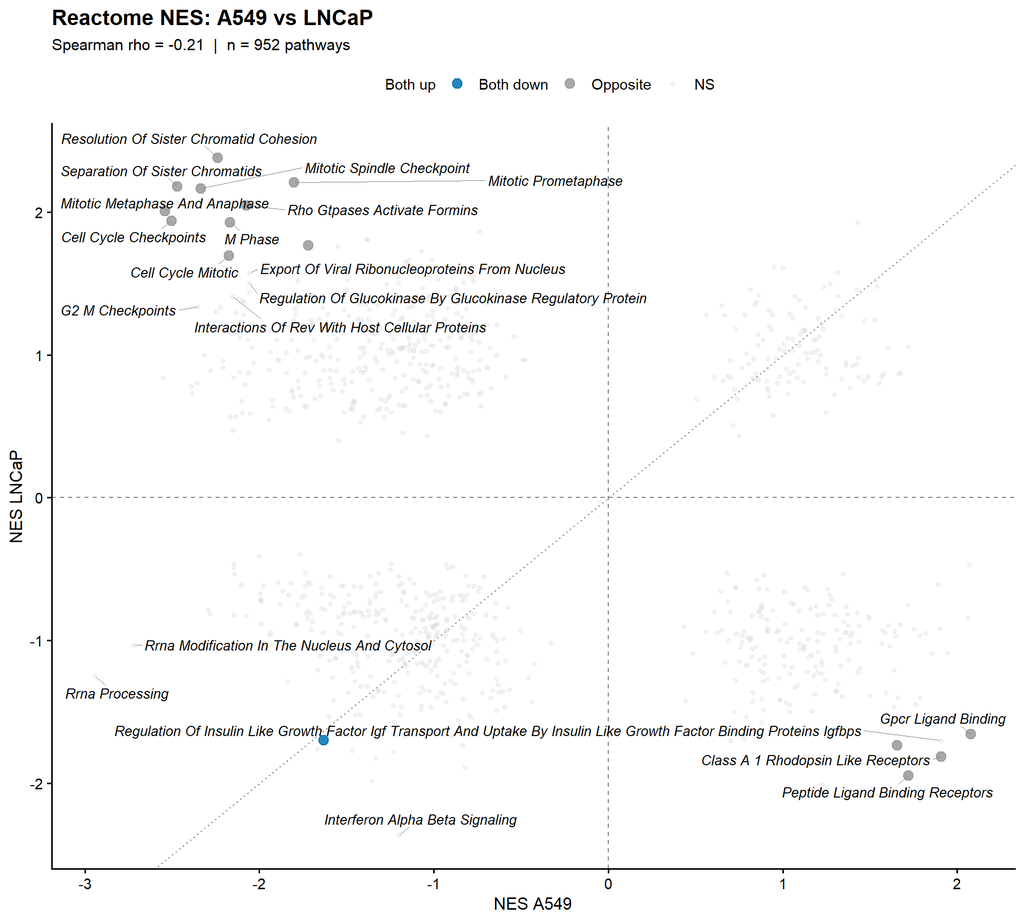

```
## Saved: reactome_nes_scatter_A549_vs_LNCaP.(png|pdf)  [10x9 in]
```

### KEGG

#### HT1080 vs A549

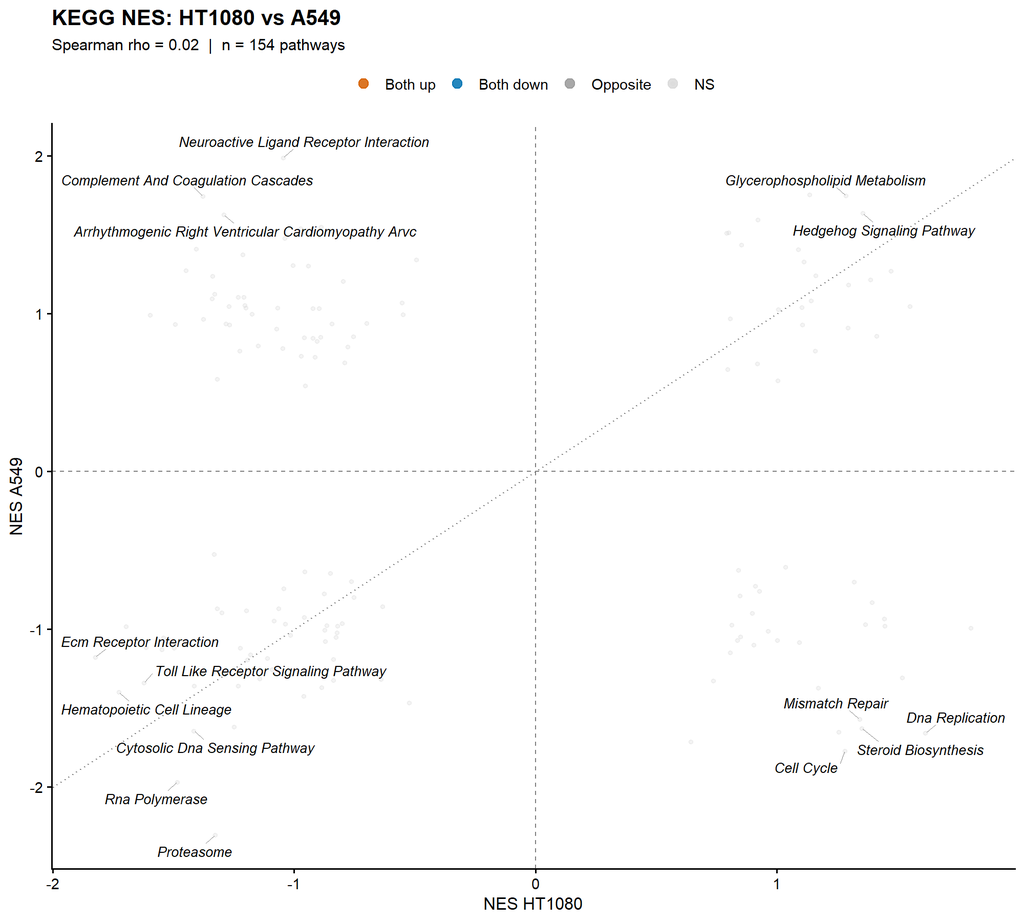

```
## Saved: kegg_nes_scatter_HT1080_vs_A549.(png|pdf)  [10x9 in]
```

#### HT1080 vs LNCaP

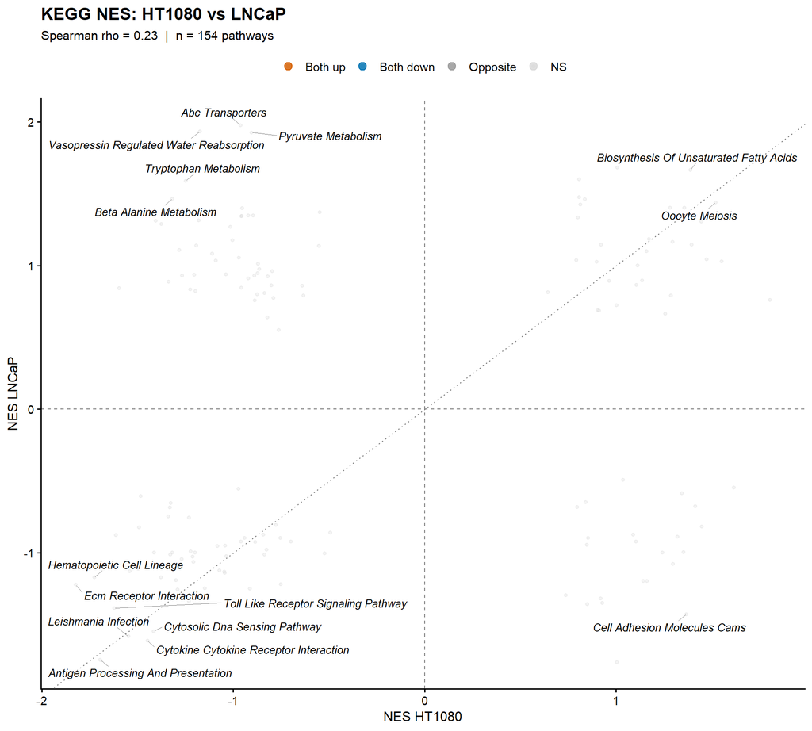

```
## Saved: kegg_nes_scatter_HT1080_vs_LNCaP.(png|pdf)  [10x9 in]
```

#### A549 vs LNCaP

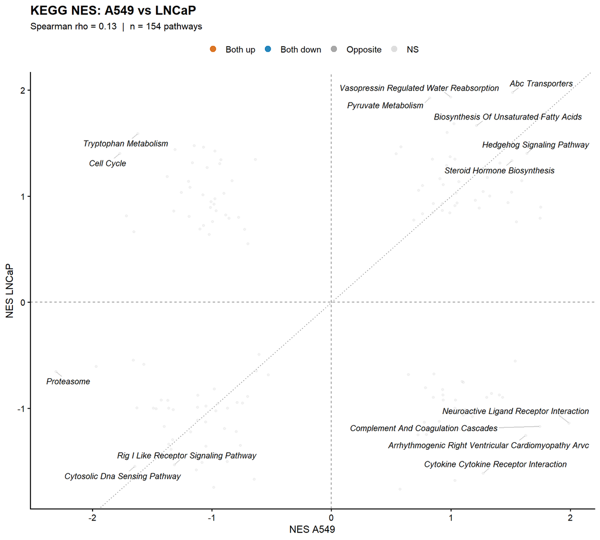

```
## Saved: kegg_nes_scatter_A549_vs_LNCaP.(png|pdf)  [10x9 in]
```

### GO:BP

#### HT1080 vs A549

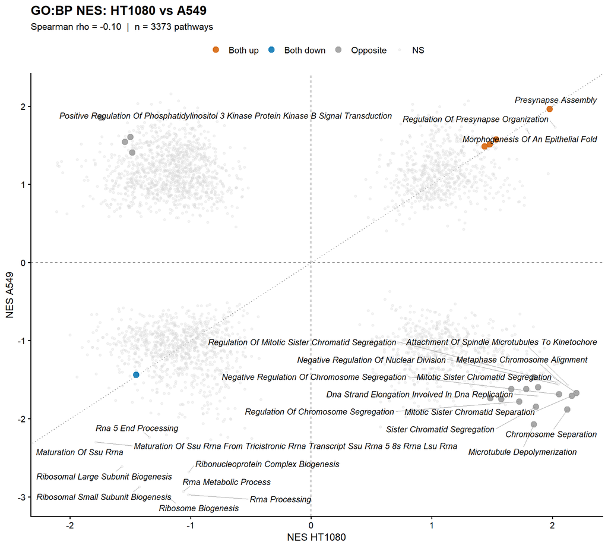

```
## Saved: gobp_nes_scatter_HT1080_vs_A549.(png|pdf)  [10x9 in]
```

#### HT1080 vs LNCaP

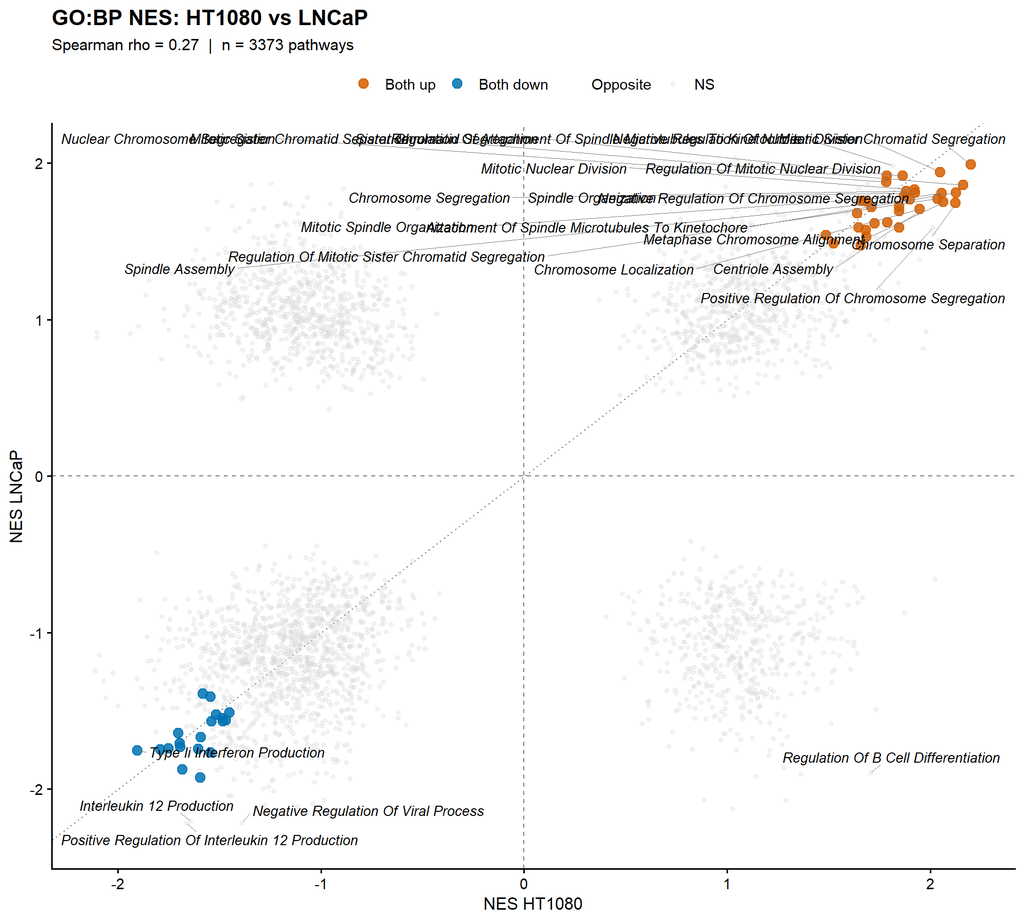

```
## Saved: gobp_nes_scatter_HT1080_vs_LNCaP.(png|pdf)  [10x9 in]
```

#### A549 vs LNCaP

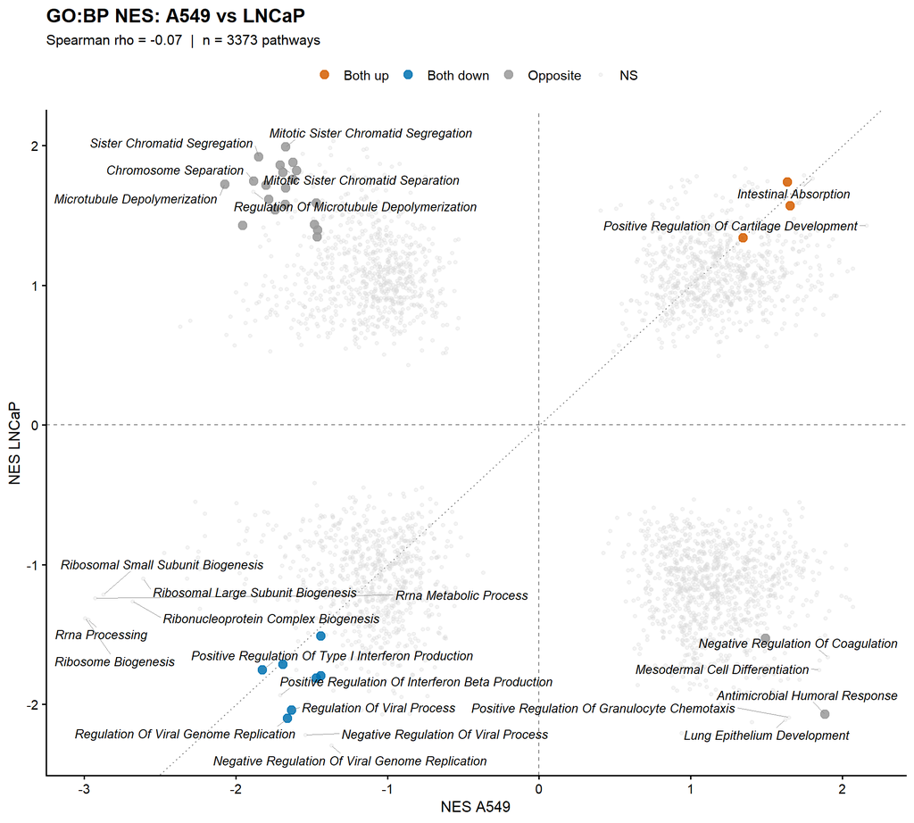

```
## Saved: gobp_nes_scatter_A549_vs_LNCaP.(png|pdf)  [10x9 in]
```

## 6.6 Three-axis NES scatter — pathway collections

Each tab: one collection (Hallmark / Reactome / KEGG / GO:BP). Axes = HT1080 / A549 / LNCaP NES. Pathways near the **x = y = z diagonal** are concordant LOY responses across all three cell lines; off-diagonal pathways are line-specific. Sign-concordance class is computed at `padj < ALPHA` (0.05) in **all three lines**. Top concordant pathways (by `|NES_HT1080| + |NES_A549| + |NES_LNCaP|`) are labelled — label count scales with collection size.

### Hallmark

```
## Hallmark: 50 pathways; concordant sig (all 3 lines): 0 up / 1 down
```

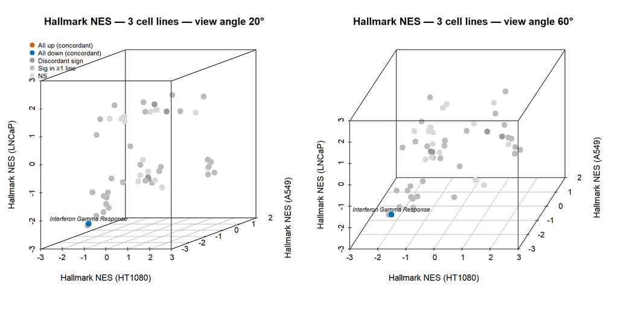

```
## Saved: 3D_NES_hallmark.(png|pdf)
```

### Reactome

```
## Reactome: 952 pathways; concordant sig (all 3 lines): 0 up / 0 down
```

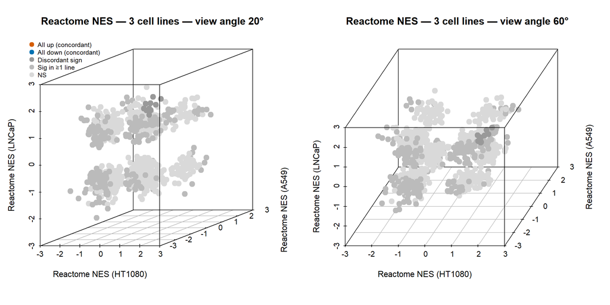

```
## Saved: 3D_NES_reactome.(png|pdf)
```

### KEGG

```
## KEGG: 154 pathways; concordant sig (all 3 lines): 0 up / 0 down
```

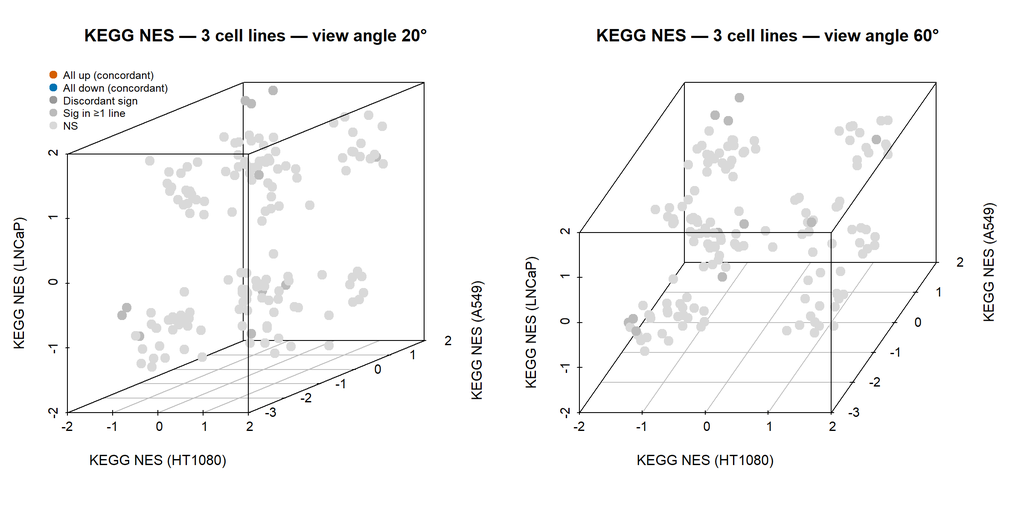

```
## Saved: 3D_NES_kegg.(png|pdf)
```

### GO:BP

```
## GO:BP: 3373 pathways; concordant sig (all 3 lines): 0 up / 1 down
```

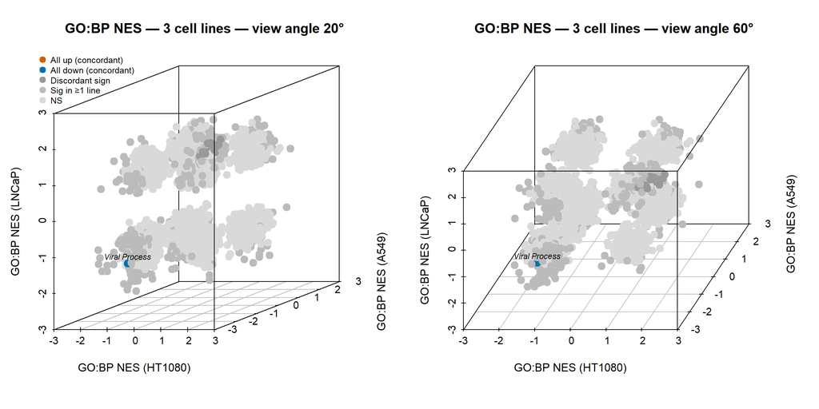

```
## Saved: 3D_NES_gobp.(png|pdf)
```

# 7. TF overlap — DoRothEA

## 7.1 Wide NES matrix

```
## DoRothEA TFs scored in all 3 lines: 229
```

Significant DoRothEA TFs per line (padj<0.05)

| cell_line | n_act | n_rep |
| --- | --- | --- |
| A549 | 3 | 1 |
| HT1080 | 3 | 10 |
| LNCaP | 6 | 7 |

## 7.2 3-way Venn — significant TFs

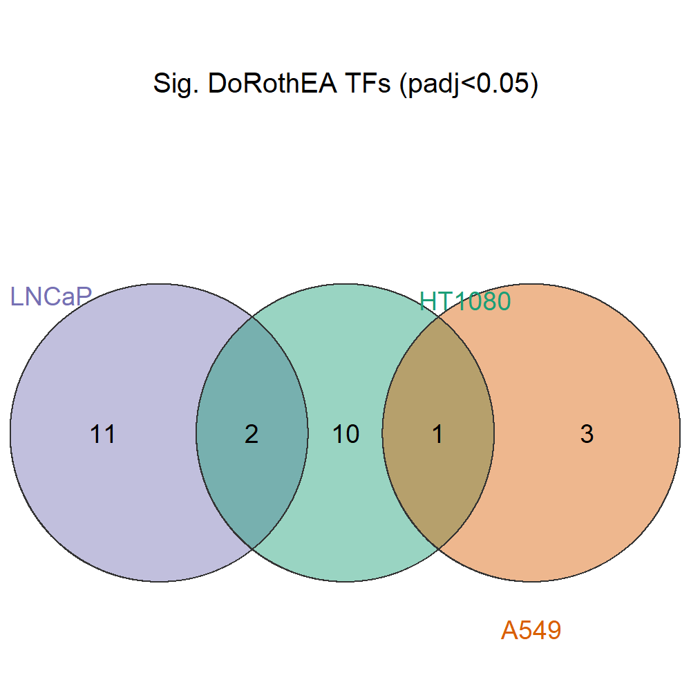

```
## Saved: venn_dorothea_sig.(png|pdf)  [5x5 in]
```

```
##
## DoRothEA TFs significant in all 3 lines: 0
```

## 7.3 DoRothEA NES heatmap (top 30 by mean |NES|)

```
## Saved: dorothea_nes_heatmap.(png|pdf)  [5.5x8 in]
```

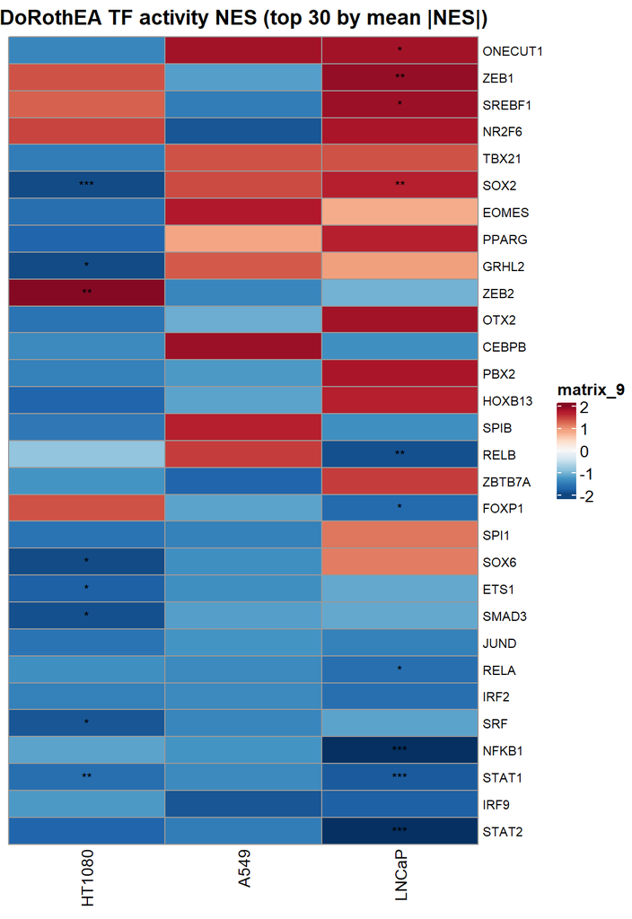

## 7.4 Pairwise NES scatter (DoRothEA)

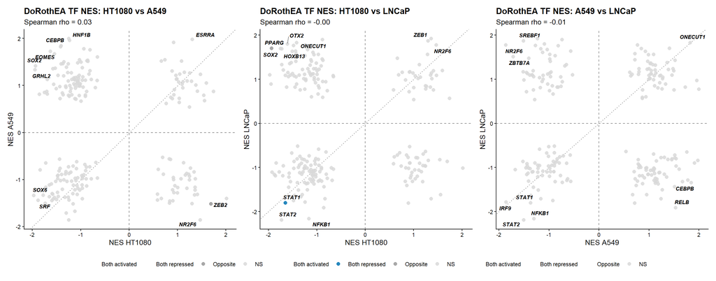

```
## Saved: dorothea_nes_scatter_pairwise.(png|pdf)  [14x5.5 in]
```

# 8. TF overlap — decoupleR (parallel check)

## 8.1 Wide score matrix

```
## decoupleR TFs scored in all 3 lines: 623
```

## 8.2 decoupleR score heatmap (top 30 by mean |score|)

```
## Saved: decoupleR_score_heatmap.(png|pdf)  [5.5x8 in]
```

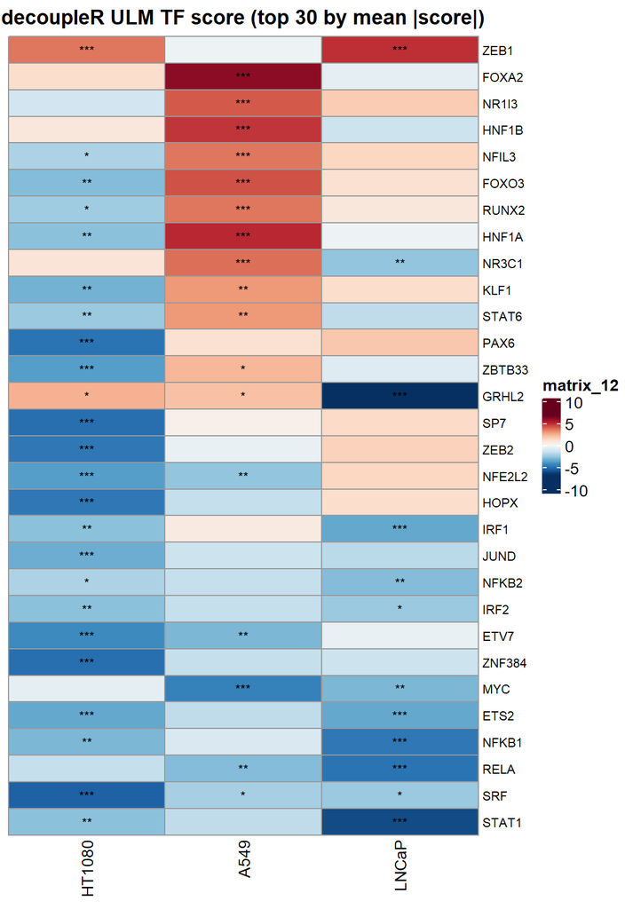

## 8.3 DoRothEA-vs-decoupleR concordance (per cell line)

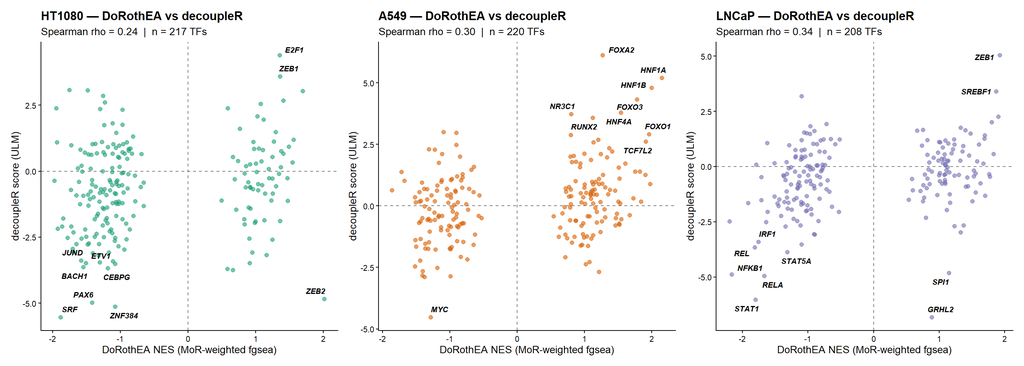

```
## Saved: dorothea_vs_decoupleR_per_cell.(png|pdf)  [14x5 in]
```

## 8.4 Three-axis decoupleR score scatter

Axes = HT1080 / A549 / LNCaP decoupleR ULM score. TFs near the diagonal are LOY-concordant master regulators across all three lines. Sign-concordance class computed at `p_value < ALPHA` (0.05) in **all three lines**; NS background drawn light. Top concordant TFs (by `sum(|score|)`) labelled.

```
## decoupleR: 623 TFs; concordant sig (all 3 lines): 0 up / 1 down
```

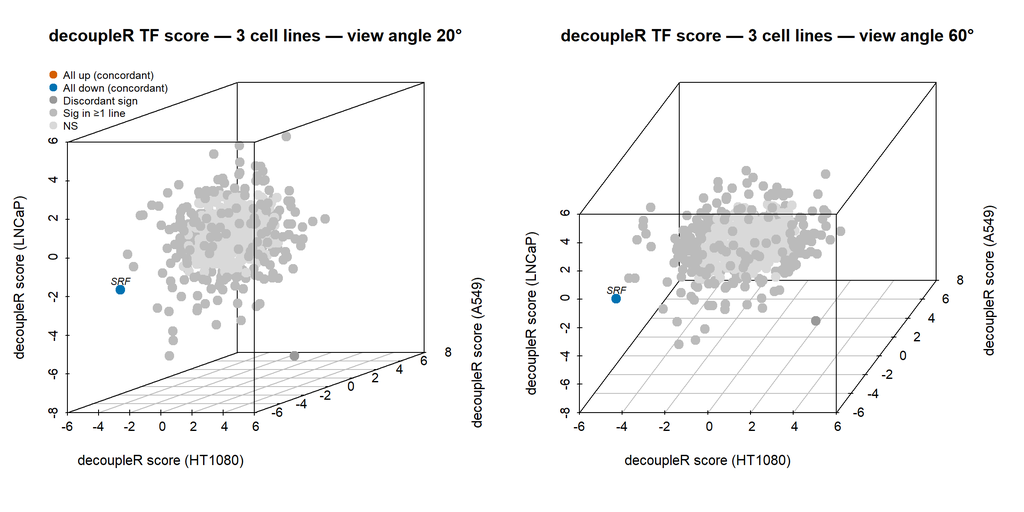

```
## Saved: 3D_decoupleR_score.(png|pdf)
```

# 9. Summary table + 3-way concordant calls

Per-cell-line summary

|  | cell_line | n_DEG_up | n_DEG_down | n_Hallmark_sig_up | n_Hallmark_sig_down | n_DoRothEA_sig_act | n_DoRothEA_sig_rep |
| --- | --- | --- | --- | --- | --- | --- | --- |
| HT1080 | HT1080 | 197 | 302 | 7 | 11 | 3 | 10 |
| A549 | A549 | 0 | 0 | 6 | 12 | 3 | 1 |
| LNCaP | LNCaP | 15 | 49 | 8 | 13 | 6 | 7 |

```
##
## 3-way concordant Hallmark pathways (NES sign agrees in all 3):
```

```
## # A tibble: 10 × 5
##    pathway                                    HT1080  A549 LNCaP mean_NES
##    <chr>                                       <dbl> <dbl> <dbl>    <dbl>
##  1 HALLMARK_INTERFERON_ALPHA_RESPONSE          -2.19 -1.27 -2.55    -2.00
##  2 HALLMARK_INTERFERON_GAMMA_RESPONSE          -2.05 -1.40 -2.46    -1.97
##  3 HALLMARK_INFLAMMATORY_RESPONSE              -1.81 -1.25 -2.20    -1.75
##  4 HALLMARK_TNFA_SIGNALING_VIA_NFKB            -1.20 -1.60 -2.00    -1.60
##  5 HALLMARK_EPITHELIAL_MESENCHYMAL_TRANSITION  -1.87 -1.39 -1.34    -1.53
##  6 HALLMARK_IL6_JAK_STAT3_SIGNALING            -1.41 -1.02 -1.98    -1.47
##  7 HALLMARK_ALLOGRAFT_REJECTION                -1.44 -1.14 -1.81    -1.46
##  8 HALLMARK_APOPTOSIS                          -1.57 -1.11 -1.53    -1.40
##  9 HALLMARK_P53_PATHWAY                        -1.06 -1.59 -1.48    -1.38
## 10 HALLMARK_FATTY_ACID_METABOLISM               1.09  1.38  1.46     1.31
```

```
##
## 3-way concordant DoRothEA TFs:
```

```
## # A tibble: 10 × 5
##    pathway HT1080  A549 LNCaP mean_NES
##    <chr>    <dbl> <dbl> <dbl>    <dbl>
##  1 STAT2    -1.73 -1.51 -2.19    -1.81
##  2 IRF9     -1.24 -1.86 -1.78    -1.63
##  3 STAT1    -1.65 -1.37 -1.80    -1.61
##  4 NFKB1    -1.16 -1.30 -2.16    -1.54
##  5 SRF      -1.88 -1.44 -1.16    -1.49
##  6 IRF2     -1.46 -1.36 -1.64    -1.49
##  7 RELA     -1.33 -1.37 -1.67    -1.46
##  8 JUND     -1.58 -1.31 -1.45    -1.45
##  9 SMAD3    -1.92 -1.22 -1.11    -1.42
## 10 ETS1     -1.77 -1.33 -1.10    -1.40
```

# 10. msVIPER cross-cell-line concordance

> **TODO.** Lands once the per-cell-line VIPER notebooks (`2.1.3`, `2.2.3`, `2.3.3`) are migrated — they produce the `viper_objects_*.rds` bundles consumed here. The cross-cell-line plan mirrors §7 (NES heatmap + 3-way Venn + pairwise scatter) but on msVIPER NES values for both the CollecTRI and tissue-matched ARACNe regulons.